# Capstone: Cyclistic Customers

Victor Ofili

2022-09-07

#### **Purpose**:

Recent financial analysis has shown that annual memberships generated the biggest revenue to the business and there is the belief that this segment of customers will be key to future business growth. The Director of Marketing and my manager has set a clear goal: Design marketing strategies aimed at converting casual riders into annual members. My task is to find out how annual members and casual riders use Cyclistic bikes differently.

#### **Statement of the Business Task**

The business task is to convert casual riders into annual members.

I am to find out how annual members and casual riders use Cyclistic bikes differently.

Insights from this task can reveal factors which can help boost annual memberships and help formulate steps aimed at convincing casual riders to switch to annual memberships.

#### **Major Stakeholders**:

1. Executive team
2. Director of Marketing (Lily Moreno)

#### **Data Preparation**

1. I downloaded files about historical trip dataset from Amazon aws. https://divvy-tripdata.s3.amazonaws.com/index.html. The dataset, owned by Motivate International Inc, is open source.
2. The downloaded dataset consisted of files spanning from August 2021 to July 2022.
3. Upon inspection, I found the data in each file to be structured and having a wide format and comprising 13 variables and several hundred thousand rows.
4. The data across the variables were of different types and formats.
5. The original variables or column names include: “ride_id”, “rideable_type”, “started_at”, “ended_at”, “start_station_name”, “start_station_id”, “end_station_name”, “end_station_id”, “start_lat”, “start_lng”, “end_lat”, “end_lng” and “member_casual”.
6. Although the columns had some missing values, there was ample information for analysis.

#### **Data Processing**

Here is my dataset comprising my csv cleaned files:

```r
Jul_2021<- read.csv("~/Data Analytics/Case Study/Original Files/Tripdata in csv/202107-divvy-tripdata.csv")
Aug_2021<- read.csv("~/Data Analytics/Case Study/Original Files/Tripdata in csv/202108-divvy-tripdata.csv")
Sep_2021<- read.csv("~/Data Analytics/Case Study/Original Files/Tripdata in csv/202109-divvy-tripdata.csv")
Oct_2021<- read.csv("~/Data Analytics/Case Study/Original Files/Tripdata in csv/202110-divvy-tripdata.csv")
Nov_2021<- read.csv("~/Data Analytics/Case Study/Original Files/Tripdata in csv/202111-divvy-tripdata.csv")
Dec_2021<- read.csv("~/Data Analytics/Case Study/Original Files/Tripdata in csv/202112-divvy-tripdata.csv")
Jan_2022<- read.csv("~/Data Analytics/Case Study/Original Files/Tripdata in csv/202201-divvy-tripdata.csv")
Feb_2022<- read.csv("~/Data Analytics/Case Study/Original Files/Tripdata in csv/202202-divvy-tripdata.csv")
Mar_2022<- read.csv("~/Data Analytics/Case Study/Original Files/Tripdata in csv/202203-divvy-tripdata.csv")
Apr_2022<- read.csv("~/Data Analytics/Case Study/Original Files/Tripdata in csv/202204-divvy-tripdata.csv")
May_2022<- read.csv("~/Data Analytics/Case Study/Original Files/Tripdata in csv/202205-divvy-tripdata.csv")
Jun_2022<- read.csv("~/Data Analytics/Case Study/Original Files/Tripdata in csv/202206-divvy-tripdata.csv")
Jul_2022<- read.csv("~/Data Analytics/Case Study/Original Files/Tripdata in csv/202207-divvy-tripdata.csv")
```

Combine the uploaded dataset with the following code chunk:

```r
all_trips<- bind_rows(Aug_2021,Sep_2021,Oct_2021,
              Nov_2021,Dec_2021,Jan_2022,Feb_2022,
              Mar_2022,Apr_2022,May_2022,Jun_2022,
              Jul_2022)
```

Clean up the data with the following code chunk:

```r
all_trips<- all_trips %>%
  select(-c(start_lat,start_lng,end_lat,end_lng)) %>%
  mutate(started_at=mdy_hm(started_at,tz="UTC"),
         start_date=as.Date(started_at),
         start_month=format(as.Date(started_at),"%B"),
         start_day=format(as.Date(started_at),"%d"),
         start_year=format(as.Date(started_at),"%Y"),
         start_weekday=format(as.Date(started_at),"%A"),
         ended_at=mdy_hm(ended_at,tz="UTC"),
         end_date=as.Date(ended_at),
         end_month=format(as.Date(ended_at),"%B"),
         end_day=format(as.Date(ended_at),"%d"),
         end_year=format(as.Date(ended_at),"%Y"),
         end_weekday=format(as.Date(ended_at),"%A")) %>%
  select(-c(day_of_week)) %>%
  filter(complete.cases(.)) %>%
  filter(ride_length>0.00) %>%
  mutate(ride_length=difftime(ended_at,started_at,units="mins"))%>%
  mutate(
start_weekday=factor(start_weekday,levels=c("Sunday","Monday","Tuesday","Wednesday","Thursday","Friday","Saturday")),
end_weekday=factor(end_weekday,levels=c("Sunday","Monday","Tuesday","Wednesday","Thursday","Friday","Saturday")),
start_month=factor(start_month,levels=c("July","August","September","October","November","December","January","February","March","April","May","June")),
end_month=factor(end_month,levels=c("July","August","September","October","November","December","January","February","March","April","May","June")))
```

Run the following code chunk to abbreviate the weekdays and months:

```r
all_trips<- all_trips %>%
  mutate(start_weekday=wday(started_at,label=TRUE),
         end_weekday=wday(ended_at,label=TRUE),
         start_month=month(started_at,label=TRUE),
         end_month=month(ended_at,label=TRUE))
```

Generate Beginning and Ending Dates for the Charts:

```r
mindate<-min(all_trips$start_date)
maxdate<-max(all_trips$start_date)
mindate
```

```
## [1] "2021-08-01"
```

```r
maxdate
```

```
## [1] "2022-07-31"
```

We need a mode function for our results

```r
getmode<- function(a){
  modes<- unique(a)
  modes[which.max(tabulate(match(a, modes)))]
}
```

**Aggregate statistics**

```r
Ride_length<-all_trips %>%
aggregate(ride_length~member_casual+rideable_type,FUN=mean)
all_trips %>% aggregate(distance_km~member_casual,FUN=mean)
```

```
##   member_casual distance_km
## 1        casual    2.256193
## 2        member    2.088253
```

```r
all_trips %>% aggregate(ride_length~member_casual,FUN=mean)
```

```
##   member_casual   ride_length
## 1        casual 24.34043 mins
## 2        member 12.65067 mins
```

```r
all_trips %>% aggregate(ride_length~member_casual,FUN=median)
```

```
##   member_casual ride_length
## 1        casual     14 mins
## 2        member      9 mins
```

```r
all_trips %>% aggregate(ride_length~member_casual,FUN=max)
```

```
##   member_casual ride_length
## 1        casual  41629 mins
## 2        member   1500 mins
```

```r
all_trips %>% aggregate(ride_length~member_casual,FUN=min)
```

```
##   member_casual ride_length
## 1        casual      0 mins
## 2        member      0 mins
```

```r
all_trips %>% aggregate(ride_length~member_casual,getmode)
```

```
##   member_casual ride_length
## 1        casual           8
## 2        member           5
```

```r
all_trips %>% aggregate(speed~member_casual,FUN=max)
```

```
##   member_casual   speed
## 1        casual  930.88
## 2        member 1499.04
```

```r
all_trips %>% aggregate(start_weekday~member_casual+rideable_type,getmode)
```

```
##   member_casual rideable_type start_weekday
## 1        casual  classic_bike           Sat
## 2        member  classic_bike           Tue
## 3        casual   docked_bike           Sat
## 4        casual electric_bike           Sat
## 5        member electric_bike           Thu
```

```r
Mod_weekday<- all_trips %>% aggregate(start_weekday~member_casual+rideable_type,getmode)
```

#### **Summary of Findings**

Table 1: Cyclistic Customer Behaviour

Cyclistic's Customer Behaviour

`Monthly travel stats of` **casual** `and` **member** `riders from August '21 to July '22. Average figures.`

|  | bike trips (monthly) | duration, min | distance, km | speed, km/h | peak month | peak weekday |
| --- | --- | --- | --- | --- | --- | --- |
| casual |  |  |  |  |  |  |
| classic_bike | 93,320 | 24.94 | 2.12 | 3.04 | Aug | Sat |
| docked_bike<sup>1</sup> | 18,539 | 54.25 | 2.17 | 1.99 | Aug | Sat |
| electric_bike | 95,513 | 17.95 | 2.41 | 4.24 | Jul | Sat |
| member |  |  |  |  |  |  |
| classic_bike | 159,252 | 13.27 | 1.94 | 3.97 | Aug | Tue |
| electric_bike | 120,177 | 11.83 | 2.29 | 5.09 | Jul | Thu |

Source: Motivate International Inc, Ofili Victor  
<sup>1</sup> `Only` **casual riders** `rode docked bikes, presumably for leisure, as they travelled the longest`

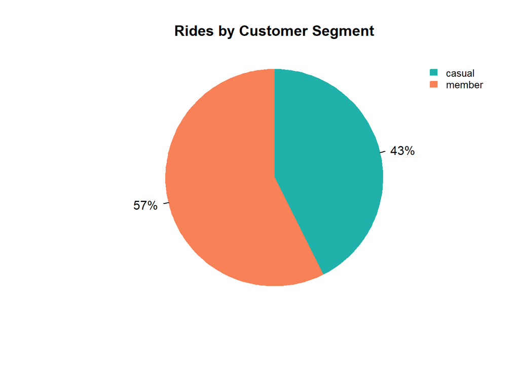

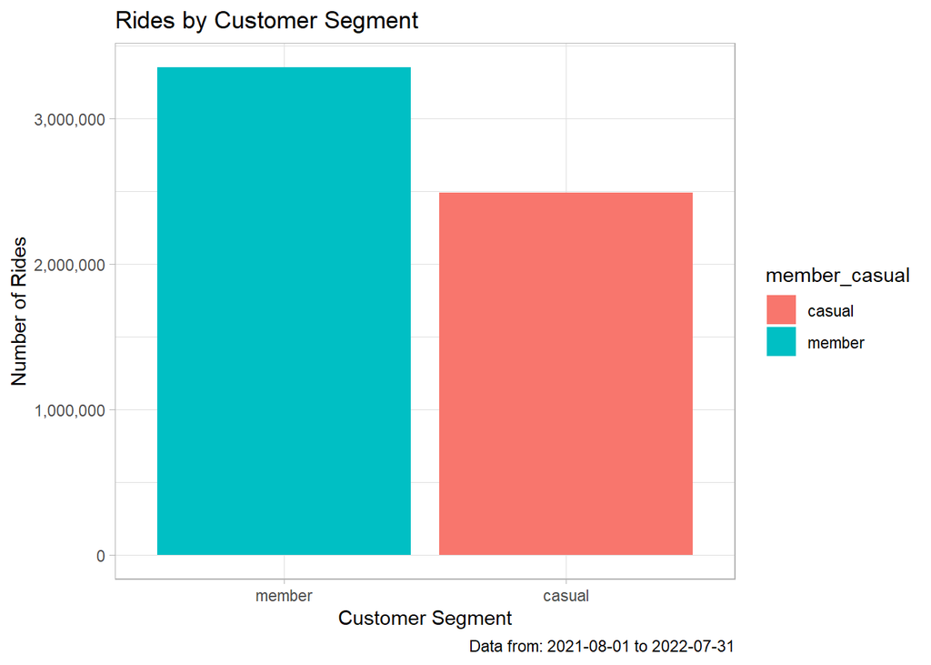

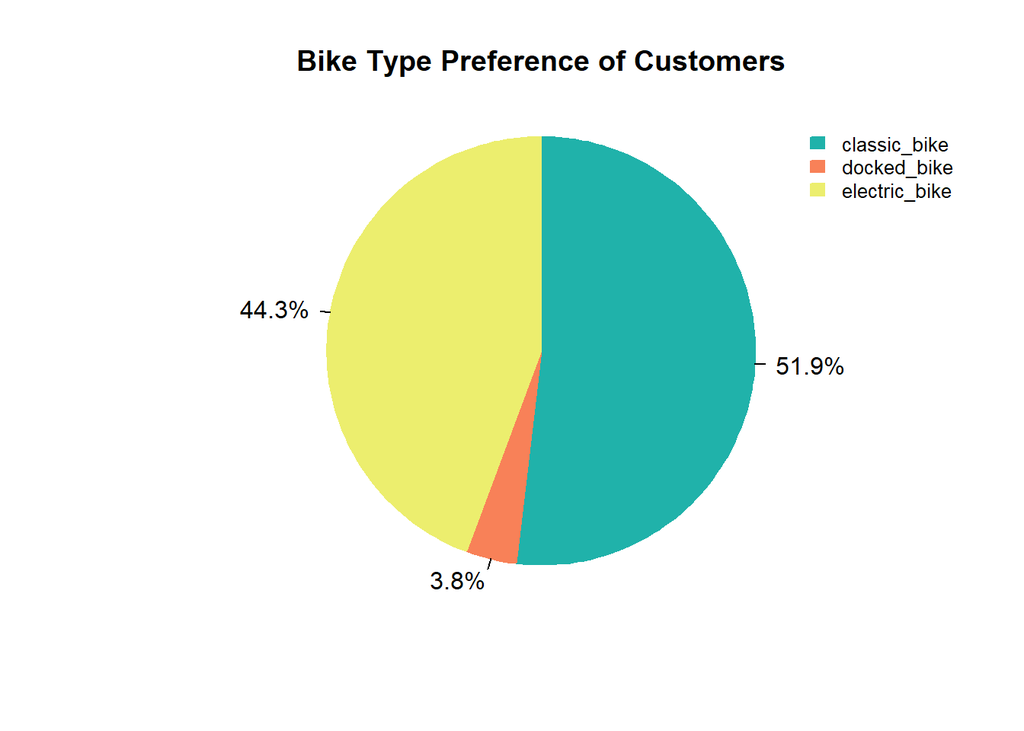

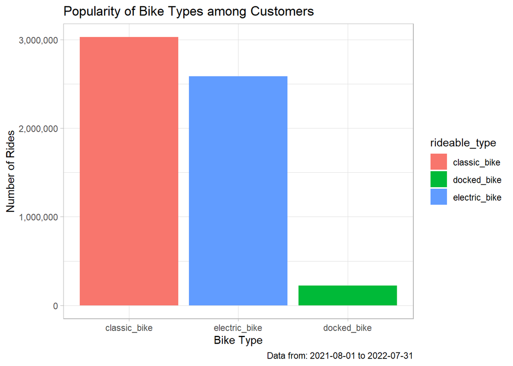

Table 2: Major Findings from Analysis

[interactive table not shown]

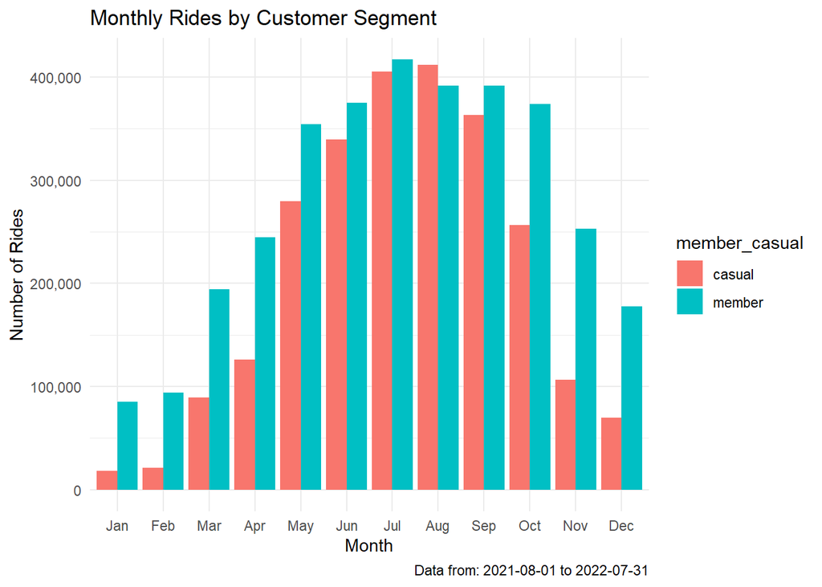

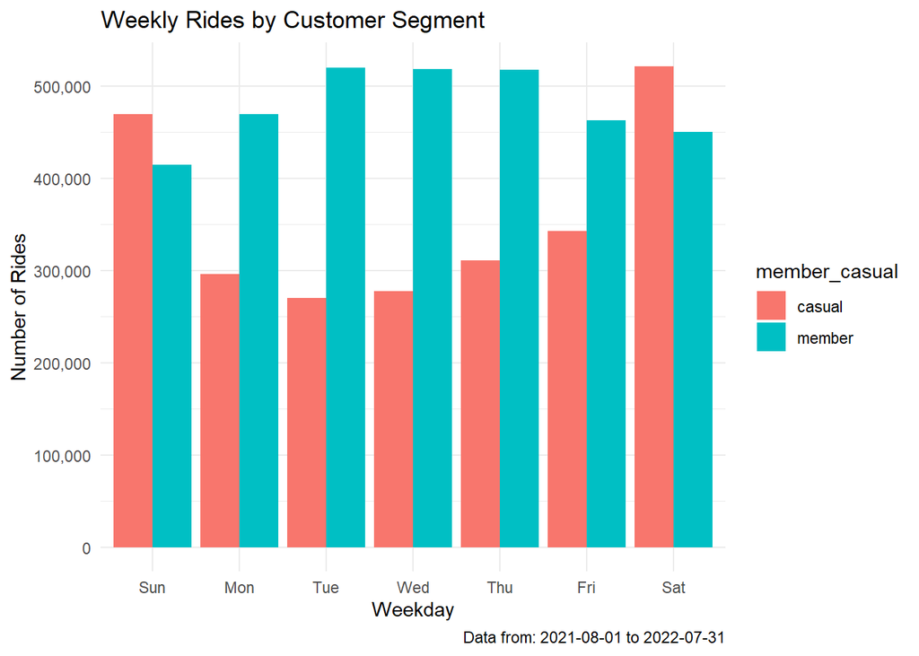

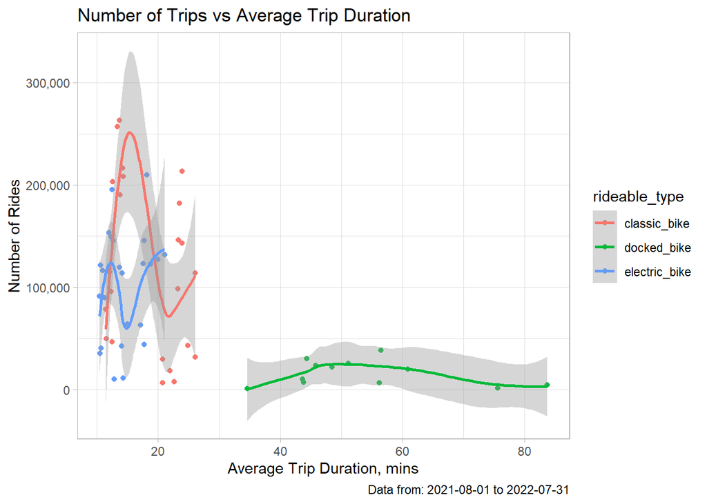

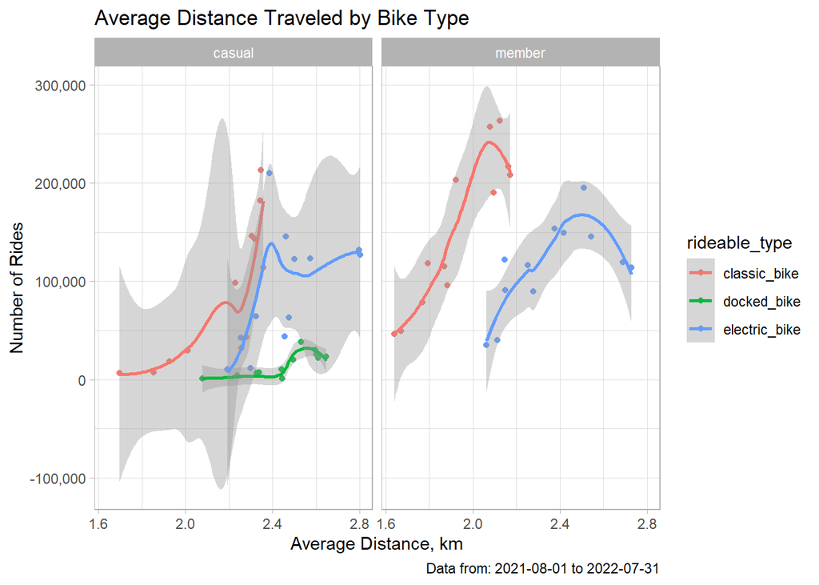

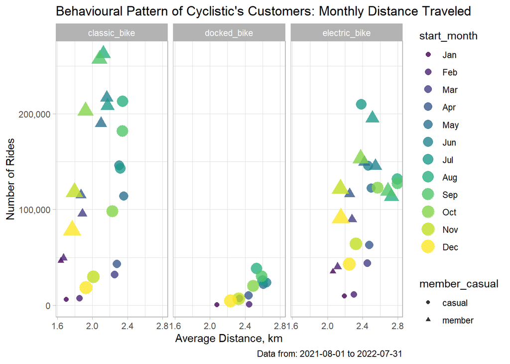

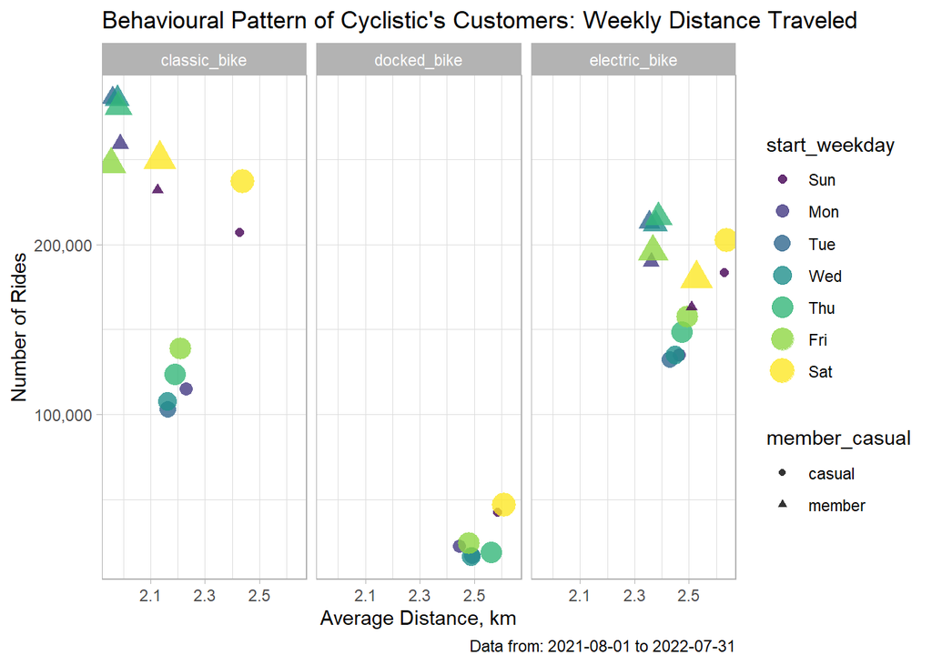

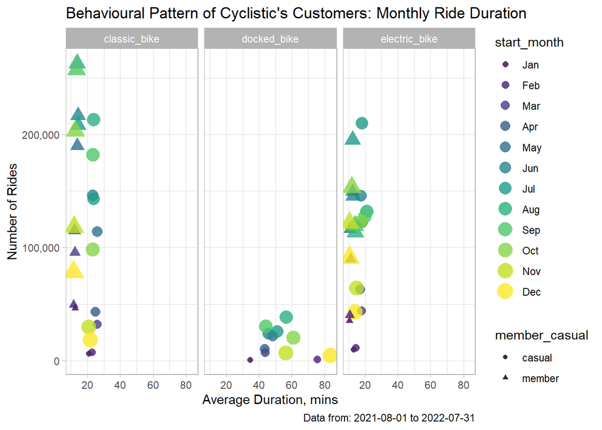

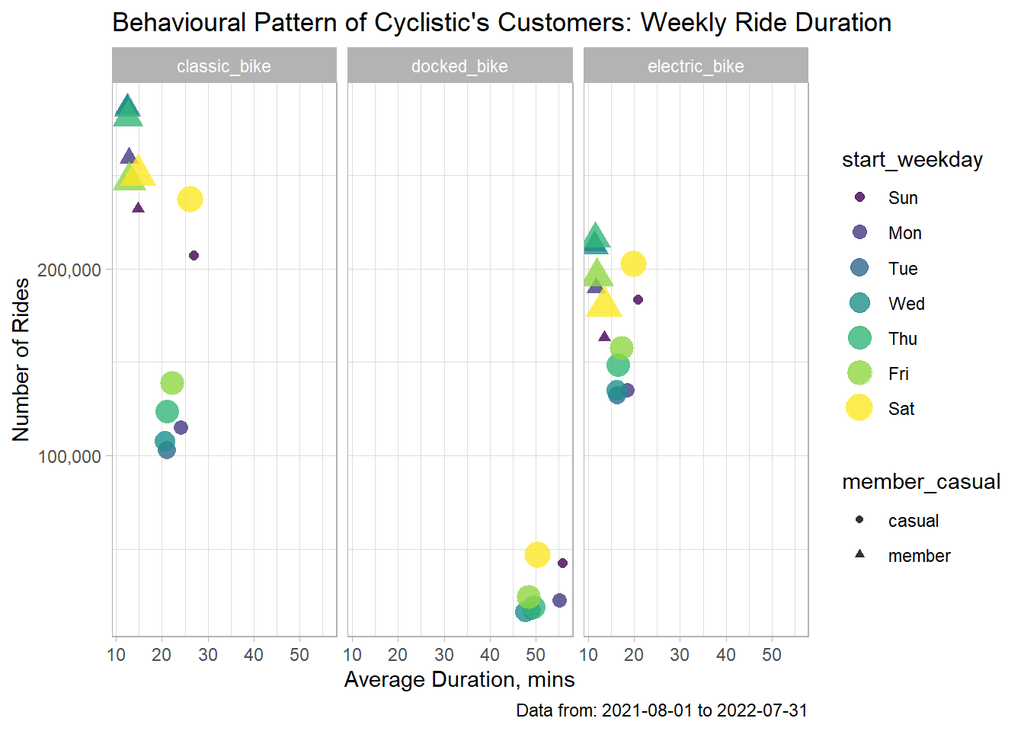

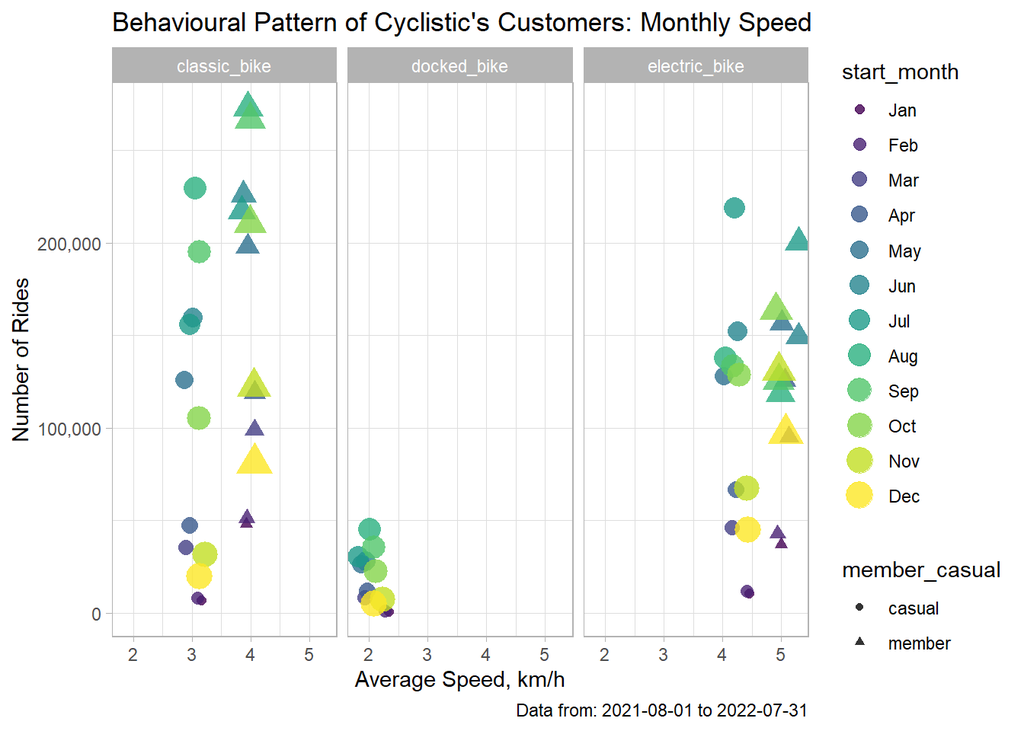

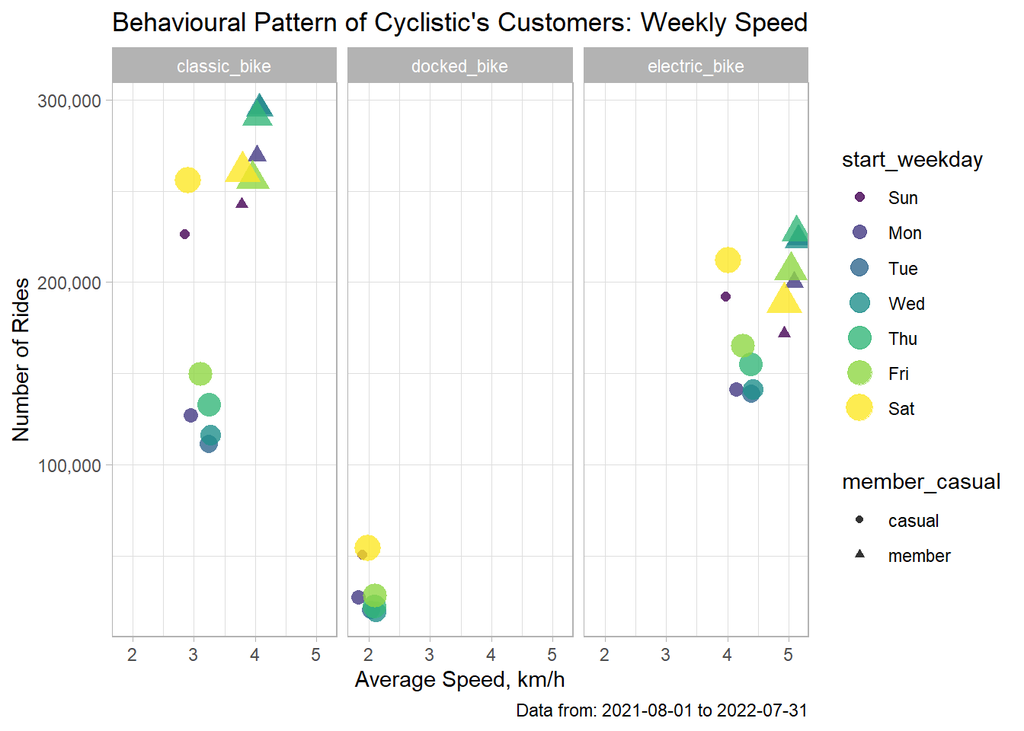

#### **My Recommendations**

In order to be able to convert Casual riders to annual members, I would recommend that our proposition to Casual riders should make them have a sense that they would derive some sort of benefit so that there is a win-win situation as against a zero-sum game. Then we will compel existing and potential Casual riders to make annual subscriptions in order to take advantage of the benefits.

1. Casual riders are the only category who used docked bikes and so the use of this bike type can easily be subjected to registration for annual memberships. From Table 01, it can be observed that the docked bikes spend the most time out of stations; hence, higher rental fee could be demanded for this bike type compared to the other types, potentially increasing profitability.
2. People generally like to be part of a good cause. Since riding bikes are considered environmentally friendly, I will recommend that Cyclistic get involved with activities tied to promoting social causes such as protection of the environment. The messaging should communicate to the Casual rider the benefits of saving the environment and that a fraction of their subscription fees could, for example, support the planting of more trees in deforested areas around the world, etc.
3. From the results of my analysis, it was observed that most Casual riders are active in spring and summer as these are the seasons when physical social activities and interactions are on the high side. I recommend that the marketing campaign message be also based on the health benefits of riding bikes while also providing networking opportunities with fellow riders to cultivate new meaningful relationships in areas of mutual interest such as business, social, etc.
4. Finally, I would recommend to my supervisor for the analytics team to conduct an online survey among existing riders to understand the target audience better and get to know their mobility needs better and their reasons for their preference for flexible plans. This will give the team more information with which to design campaign messages.